# Informe estadístico - Pingüinos Palmer

**Asignatura:** II593 - Estadística General  
**Ofertada por:** Facultad de Ciencias Empresariales  
**Profesor:** Ing. Sebastián Blandón Londoño  
Ingeniería Industrial  
Facultad de Ciencias Empresariales  
*Universidad Tecnológica de Pereira*

Autor

[Sebastián Blandón Londoño](https://www.linkedin.com/in/sebastian-blandon/)

Fecha de publicación

25/02/2025

# Preparación

## Carga de librerías

**Código**

```r
library(palmerpenguins) # Datos de los pinguinos
library(janitor) # Para limpiar rapidamente los datos (nombres de las variables, etc...)
library(tidyverse) # Meta-paquete con librerias para transformar datos, crear graficas y otras
library(skimr) # Para hacer el resumen rapido del dataset
library(DT) # Para mostrar tablas interactivas
```

## Carga de datos

**Código**

```r
datos_pinguinos <- penguins_raw
```

## Limpieza de datos

**Código**

```r
# Limpiar los nombres de las columnas (variables)
datos_pinguinos <- datos_pinguinos %>%
  clean_names()

# Especificar el tipo de variable
datos_pinguinos <- datos_pinguinos %>%
  mutate(
    study_name = as_factor(study_name),
    sample_number = as_factor(sample_number),
    species = as_factor(species),
    region = as_factor(region),
    island = as_factor(island),
    stage = as_factor(stage),
    individual_id = as_factor(individual_id),
    clutch_completion = as_factor(clutch_completion),
    date_egg = as_date(date_egg),
    culmen_length_mm = as.numeric(culmen_length_mm),
    culmen_depth_mm = as.numeric(culmen_depth_mm),
    flipper_length_mm = as.numeric(flipper_length_mm),
    body_mass_g = as.numeric(body_mass_g),
    sex = as_factor(sex),
    delta_15_n_o_oo = as.numeric(delta_15_n_o_oo),
    delta_13_c_o_oo = as.numeric(delta_13_c_o_oo)
  ) %>%
  as_tibble()
```

# Resumen rápido de los datos

**Código**

```r
datos_pinguinos %>%
  skim()
```

Data summary

| Name | Piped data |
| --- | --- |
| Number of rows | 344 |
| Number of columns | 17 |
| _______________________ |  |
| Column type frequency: |  |
| character | 1 |
| Date | 1 |
| factor | 9 |
| numeric | 6 |
| ________________________ |  |
| Group variables | None |

**Variable type: character**

| skim_variable | n_missing | complete_rate | min | max | empty | n_unique | whitespace |
| --- | --- | --- | --- | --- | --- | --- | --- |
| comments | 290 | 0.16 | 18 | 68 | 0 | 10 | 0 |

**Variable type: Date**

| skim_variable | n_missing | complete_rate | min | max | median | n_unique |
| --- | --- | --- | --- | --- | --- | --- |
| date_egg | 0 | 1 | 2007-11-09 | 2009-12-01 | 2008-11-09 | 50 |

**Variable type: factor**

| skim_variable | n_missing | complete_rate | ordered | n_unique | top_counts |
| --- | --- | --- | --- | --- | --- |
| study_name | 0 | 1.00 | FALSE | 3 | PAL: 120, PAL: 114, PAL: 110 |
| sample_number | 0 | 1.00 | FALSE | 152 | 1: 3, 2: 3, 3: 3, 4: 3 |
| species | 0 | 1.00 | FALSE | 3 | Ade: 152, Gen: 124, Chi: 68 |
| region | 0 | 1.00 | FALSE | 1 | Anv: 344 |
| island | 0 | 1.00 | FALSE | 3 | Bis: 168, Dre: 124, Tor: 52 |
| stage | 0 | 1.00 | FALSE | 1 | Adu: 344 |
| individual_id | 0 | 1.00 | FALSE | 190 | N6A: 3, N6A: 3, N8A: 3, N8A: 3 |
| clutch_completion | 0 | 1.00 | FALSE | 2 | Yes: 308, No: 36 |
| sex | 11 | 0.97 | FALSE | 2 | MAL: 168, FEM: 165 |

**Variable type: numeric**

| skim_variable | n_missing | complete_rate | mean | sd | p0 | p25 | p50 | p75 | p100 | hist |
| --- | --- | --- | --- | --- | --- | --- | --- | --- | --- | --- |
| culmen_length_mm | 2 | 0.99 | 43.92 | 5.46 | 32.10 | 39.23 | 44.45 | 48.50 | 59.60 | ▃▇▇▆▁ |
| culmen_depth_mm | 2 | 0.99 | 17.15 | 1.97 | 13.10 | 15.60 | 17.30 | 18.70 | 21.50 | ▅▅▇▇▂ |
| flipper_length_mm | 2 | 0.99 | 200.92 | 14.06 | 172.00 | 190.00 | 197.00 | 213.00 | 231.00 | ▂▇▃▅▂ |
| body_mass_g | 2 | 0.99 | 4201.75 | 801.95 | 2700.00 | 3550.00 | 4050.00 | 4750.00 | 6300.00 | ▃▇▆▃▂ |
| delta_15_n_o_oo | 14 | 0.96 | 8.73 | 0.55 | 7.63 | 8.30 | 8.65 | 9.17 | 10.03 | ▃▇▆▅▂ |
| delta_13_c_o_oo | 13 | 0.96 | -25.69 | 0.79 | -27.02 | -26.32 | -25.83 | -25.06 | -23.79 | ▆▇▅▅▂ |

# Preguntas

## 1. ¿Cuántos pingüinos machos hay en la isla de Dream, Torgersen y Biscoe?

**Código**

```r
cantidad_machos <- datos_pinguinos %>%
  filter(sex == "MALE") %>%
  group_by(island) %>%
  summarise(
    cantidad = n()
  ) %>%
  arrange(-cantidad) %>%
  ungroup()

# Para mostrar la tabla
cantidad_machos %>%
  datatable()
```

|  | island | cantidad |
| --- | --- | --- |
| 1 | Biscoe | 83 |
| 2 | Dream | 62 |
| 3 | Torgersen | 23 |

**Código**

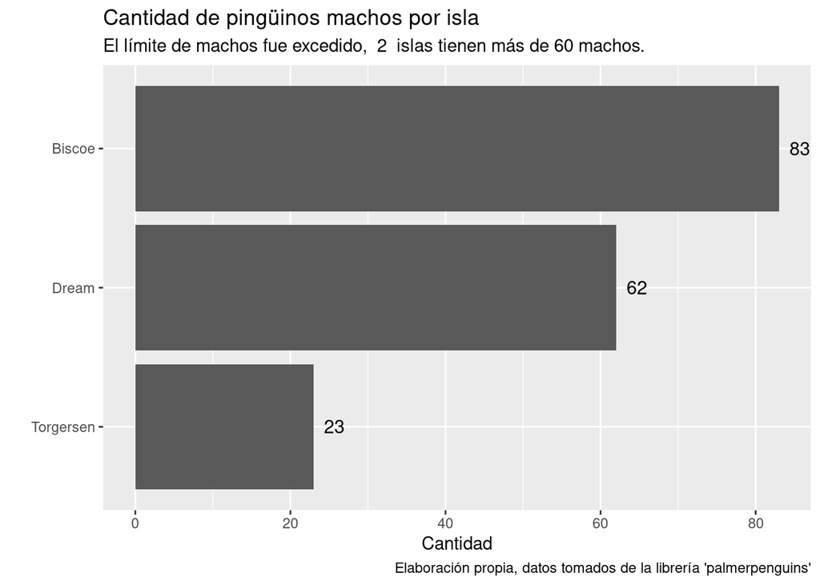

```r
# Para mostrar el gráfico de barras
max_machos <- max(cantidad_machos$cantidad)
Qty_exceden <- length(cantidad_machos$cantidad[cantidad_machos$cantidad>60])

cantidad_machos %>%
  mutate(island = fct_reorder(island, cantidad)) %>%
  ggplot(mapping = aes(x = island,
                       y = cantidad))+
  geom_bar(stat = "identity")+
  coord_flip()+
  labs(title = "Cantidad de pingüinos machos por isla",
       subtitle = if_else(max_machos > 60,
                          paste("El límite de machos fue excedido, ", Qty_exceden, " islas tienen más de 60 machos."),
                          "El límite de machos no ha sido excedido."),
       x = "",
       y = "Cantidad",
       caption = "Elaboración propia, datos tomados de la librería 'palmerpenguins'"
       )+
  geom_text(aes(label = cantidad), hjust = -0.5, size = 4)
```

Tomando en cuenta los resultados ilustrados tanto en la tabla como en el gráfico, es posible evidenciar que la isla Biscoe tiene 83 pingüinos machos, mientras que las islas Dream y Torgersen tienen 62 y 23 respectivamente.

## 2. ¿Cuántos pingüinos tienen su sexo definido?

En total, fue posible identificar el sexo de 333 pingüinos. Gráficamente, se tiene la siguiente relación:

**Código**

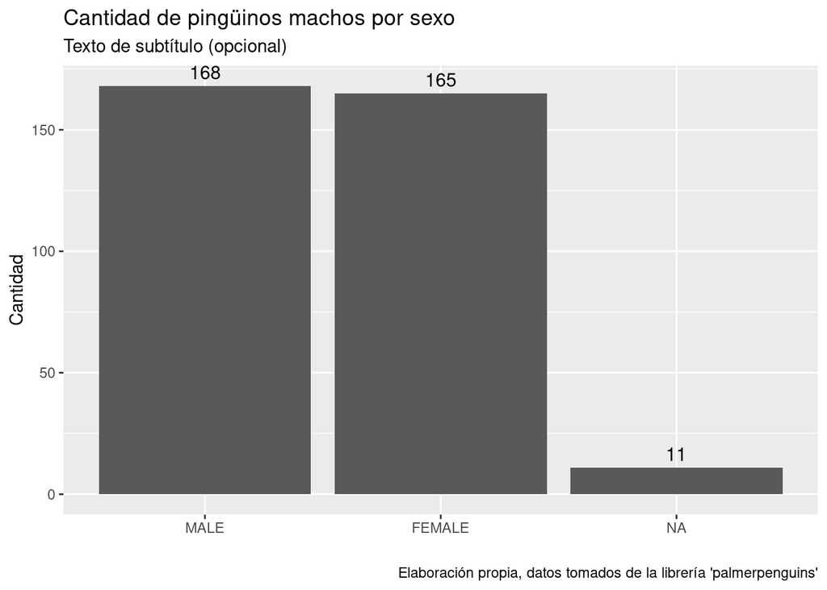

```r
# Alternativa 1
datos_pinguinos %>%
  group_by(sex) %>%
  summarise(
    cantidad = n()
  ) %>%
  ggplot(mapping = aes(x = sex,
                       y = cantidad))+
  geom_bar(stat = "identity")+
  labs(title = "Cantidad de pingüinos machos por sexo",
       subtitle = "Texto de subtítulo (opcional)",
       x = "",
       y = "Cantidad",
       caption = "Elaboración propia, datos tomados de la librería 'palmerpenguins'")+
  geom_text(aes(label = cantidad), vjust = -0.5, size = 4)
```

**Código**

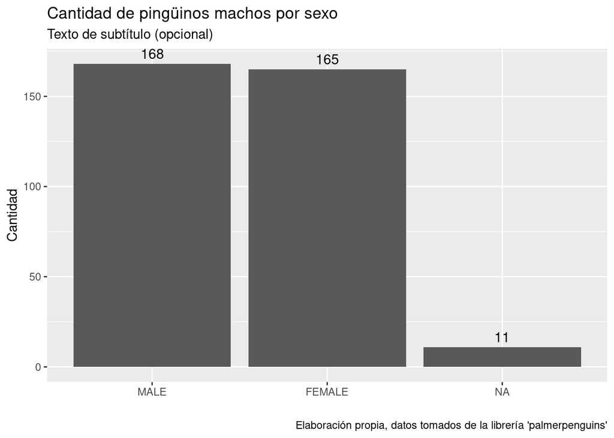

```r
# Alternativa 2
datos_pinguinos %>%
  ggplot(aes(x = sex))+
    geom_bar()+
    labs(title = "Cantidad de pingüinos machos por sexo",
         subtitle = "Texto de subtítulo (opcional)",
         x = "",
         y = "Cantidad",
         caption = "Elaboración propia, datos tomados de la librería 'palmerpenguins'")+
  geom_text(stat = "count", aes(label = after_stat(count)), vjust = -0.5, size = 4)
```

## 3. ¿Cuál es la proporción de machos y hembras?

**Código**

```r
proporcion_sexo <- datos_pinguinos %>%
  group_by(sex) %>%
  summarise(
    proporcion = round(n() / nrow(datos_pinguinos), digits = 4)
  ) %>%
  ungroup()
```

En total, la concentración de hembras y machos es de 47.97 % y 48.84 % respectivamente. Asimismo, un 3.2 % de los pingüinos no tuvieron una plena identificación de sexo, lo cual representa 11 ejemplares.

## 4. ¿Cuál especie tiene mayor cantidad de población en las islas?

**Código**

```r
poblacion_especie <- datos_pinguinos %>%
  group_by(species) %>%
  summarise(
    cantidad = n()
  ) %>%
  ungroup()
```

La especie con mayor población en las islas es Adelie Penguin (Pygoscelis adeliae), con un total de 152 pingüinos. La distribución de la población se ilustra en la siguiente gráfica:

**Código**

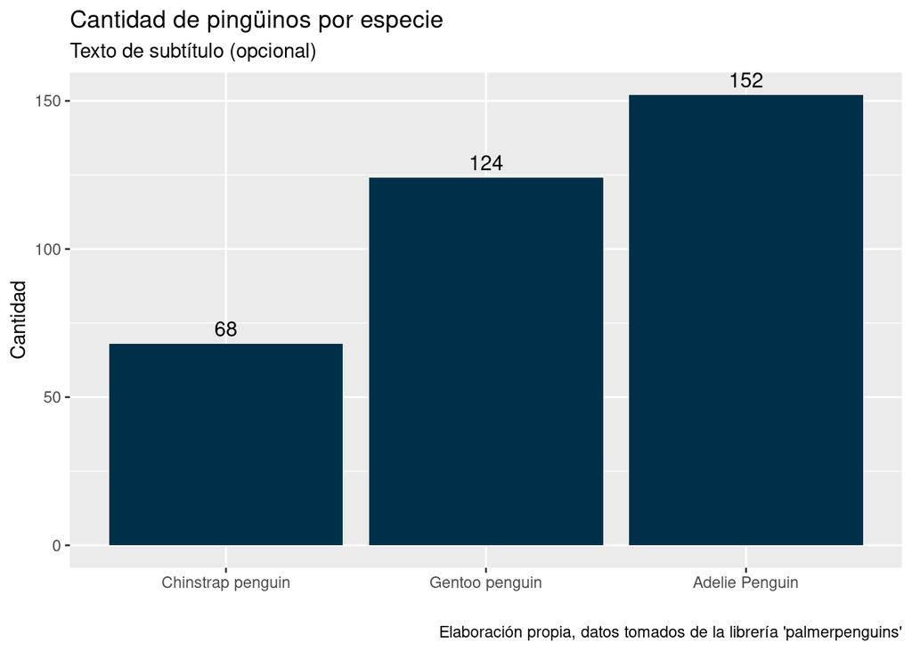

```r
poblacion_especie %>%
  mutate(species = str_replace(species, "\\s*\\(.*", "")) %>%
  ggplot(aes(x = fct_reorder(species, cantidad),
             y = cantidad))+
    geom_bar(stat = "identity", fill = "#003049")+
    labs(title = "Cantidad de pingüinos por especie",
         subtitle = "Texto de subtítulo (opcional)",
         x = "",
         y = "Cantidad",
         caption = "Elaboración propia, datos tomados de la librería 'palmerpenguins'")+
  geom_text(aes(label = cantidad), vjust = -0.5, size = 4)
```

## 5. ¿Qué tamaño (largo) promedio de pico tienen los pingüinos?

**Código**

```r
promedio_pico <- round(mean(datos_pinguinos$culmen_length_mm, na.rm = TRUE), digits = 2)
```

En promedio, el largo promedio del pico de los pingüinos estudiados es de 43.92mm.

## 6. ¿Cuál es la especie de pingüinos con mayor variabilidad en la longitud del pico?

**Código**

```r
variabilidad <- datos_pinguinos %>%
  group_by(species) %>%
  summarise(
    varianza_longitud_pico = var(culmen_length_mm, na.rm = TRUE)
  )
```

Chinstrap penguin (Pygoscelis antarctica) es la especie con mayor variabilidad en la longitud del pico, sustentado en una varianza de 11.15mm y una desviación estándar de 3.34mm.

## 7. ¿Cuál especie tiene pico más largo?

Esta pregunta debe ser respondida con cautela, puesto que podría tener dos interpretaciones:

- **Interpretación 1:** se quiere saber a cuál especie corresponde el registro de longitud de pico más largo.
- **Interpretación 2:** se quiere saber cuál especie tiene en promedio la mayor longitud de pico.